# Predicting Car Prices

# Introduction

We will explore a dataset and use KNN model to predict the car prices.

This data set consists of three types of entities: (a) the specification of an auto in terms of various characteristics, (b) its assigned insurance risk rating, (c) its normalized losses in use as compared to other cars. The second rating corresponds to the degree to which the auto is more risky than its price indicates. Cars are initially assigned a risk factor symbol associated with its price. Then, if it is more risky (or less), this symbol is adjusted by moving it up (or down) the scale. Actuarians call this process “symboling”. A value of +3 indicates that the auto is risky, -3 that it is probably pretty safe.

# Attribute Information

Attribute Information:

Attribute: Attribute Range

1. symboling: -3, -2, -1, 0, 1, 2, 3.
2. normalized-losses: continuous from 65 to 256.
3. make: alfa-romero, audi, bmw, chevrolet, dodge, honda, isuzu, jaguar, mazda, mercedes-benz, mercury, mitsubishi, nissan, peugot, plymouth, porsche, renault, saab, subaru, toyota, volkswagen, volvo
4. fuel-type: diesel, gas.
5. aspiration: std, turbo.
6. num-of-doors: four, two.
7. body-style: hardtop, wagon, sedan, hatchback, convertible.
8. drive-wheels: 4wd, fwd, rwd.
9. engine-location: front, rear.
10. wheel-base: continuous from 86.6 120.9.
11. length: continuous from 141.1 to 208.1.
12. width: continuous from 60.3 to 72.3.
13. height: continuous from 47.8 to 59.8.
14. curb-weight: continuous from 1488 to 4066.
15. engine-type: dohc, dohcv, l, ohc, ohcf, ohcv, rotor.
16. num-of-cylinders: eight, five, four, six, three, twelve, two.
17. engine-size: continuous from 61 to 326.
18. fuel-system: 1bbl, 2bbl, 4bbl, idi, mfi, mpfi, spdi, spfi.
19. bore: continuous from 2.54 to 3.94.
20. stroke: continuous from 2.07 to 4.17.
21. compression-ratio: continuous from 7 to 23.
22. horsepower: continuous from 48 to 288.
23. peak-rpm: continuous from 4150 to 6600.
24. city-mpg: continuous from 13 to 49.
25. highway-mpg: continuous from 16 to 54.
26. price: continuous from 5118 to 45400.

# Data Exploration

```r
library(tidyverse)

cars <- read.csv("imports-85.data")
head(cars)
```

|  | X3 | X. | alfa.romero | gas | std | two | convertible | rwd | front | X88.60 | X168.80 | X64.10 | X48.80 | X2548 | dohc | four | X130 | mpfi | X3.47 | X2.68 | X9.00 | X111 | X5000 | X21 | X27 | X13495 |
| --- | --- | --- | --- | --- | --- | --- | --- | --- | --- | --- | --- | --- | --- | --- | --- | --- | --- | --- | --- | --- | --- | --- | --- | --- | --- | --- |
| 1 | 3 | ? | alfa-romero | gas | std | two | convertible | rwd | front | 88.6 | 168.8 | 64.1 | 48.8 | 2548 | dohc | four | 130 | mpfi | 3.47 | 2.68 | 9.0 | 111 | 5000 | 21 | 27 | 16500 |
| 2 | 1 | ? | alfa-romero | gas | std | two | hatchback | rwd | front | 94.5 | 171.2 | 65.5 | 52.4 | 2823 | ohcv | six | 152 | mpfi | 2.68 | 3.47 | 9.0 | 154 | 5000 | 19 | 26 | 16500 |
| 3 | 2 | 164 | audi | gas | std | four | sedan | fwd | front | 99.8 | 176.6 | 66.2 | 54.3 | 2337 | ohc | four | 109 | mpfi | 3.19 | 3.40 | 10.0 | 102 | 5500 | 24 | 30 | 13950 |
| 4 | 2 | 164 | audi | gas | std | four | sedan | 4wd | front | 99.4 | 176.6 | 66.4 | 54.3 | 2824 | ohc | five | 136 | mpfi | 3.19 | 3.40 | 8.0 | 115 | 5500 | 18 | 22 | 17450 |
| 5 | 2 | ? | audi | gas | std | two | sedan | fwd | front | 99.8 | 177.3 | 66.3 | 53.1 | 2507 | ohc | five | 136 | mpfi | 3.19 | 3.40 | 8.5 | 110 | 5500 | 19 | 25 | 15250 |
| 6 | 1 | 158 | audi | gas | std | four | sedan | fwd | front | 105.8 | 192.7 | 71.4 | 55.7 | 2844 | ohc | five | 136 | mpfi | 3.19 | 3.40 | 8.5 | 110 | 5500 | 19 | 25 | 17710 |

As we can see, the column names are showing like X3, X etc. But we need proper naming for the columns. Thats why we will change the column names.

```r
colnames(cars) <- c(
  "symboling",
  "normalized_losses",
  "make",
  "fuel_type",
  "aspiration",
  "num_doors",
  "body_style",
  "drive_wheels",
  "engine_location",
  "wheel_base",
  "length",
  "width",
  "height",
  "curb_weight",
  "engine_type",
  "num_cylinders",
  "engine_size",
  "fuel_system",
  "bore",
  "stroke",
  "compression_ratio",
  "horsepower",
  "peak_rpm",
  "city_mpg",
  "highway_mpg",
  "price"
)

# We will remove the non-numercial columns and filter out the missing values

cars <- cars %>%
  select(
    symboling, wheel_base, length, width, height, curb_weight,
    engine_size, bore, stroke, compression_ratio, horsepower,
    peak_rpm, city_mpg, highway_mpg, price
  ) %>%
  filter(
    stroke != "?",
    bore != "?",
    horsepower != "?",
    peak_rpm != "?",
    price != "?"
  ) %>%
  mutate(
    stroke = as.numeric(stroke),
    bore = as.numeric(bore),
    horsepower = as.numeric(horsepower),
    peak_rpm = as.numeric(peak_rpm),
    price = as.numeric(price)
  )
head(cars)
```

|  | symboling | wheel_base | length | width | height | curb_weight | engine_size | bore | stroke | compression_ratio | horsepower | peak_rpm | city_mpg | highway_mpg | price |
| --- | --- | --- | --- | --- | --- | --- | --- | --- | --- | --- | --- | --- | --- | --- | --- |
| 1 | 3 | 88.6 | 168.8 | 64.1 | 48.8 | 2548 | 130 | 25 | 6 | 9.0 | 7 | 12 | 21 | 27 | 51 |
| 2 | 1 | 94.5 | 171.2 | 65.5 | 52.4 | 2823 | 152 | 3 | 29 | 9.0 | 22 | 12 | 19 | 26 | 51 |
| 3 | 2 | 99.8 | 176.6 | 66.2 | 54.3 | 2337 | 109 | 15 | 26 | 10.0 | 4 | 18 | 24 | 30 | 37 |
| 4 | 2 | 99.4 | 176.6 | 66.4 | 54.3 | 2824 | 136 | 15 | 26 | 8.0 | 10 | 18 | 18 | 22 | 62 |
| 5 | 2 | 99.8 | 177.3 | 66.3 | 53.1 | 2507 | 136 | 15 | 26 | 8.5 | 6 | 18 | 19 | 25 | 42 |
| 6 | 1 | 105.8 | 192.7 | 71.4 | 55.7 | 2844 | 136 | 15 | 26 | 8.5 | 6 | 18 | 19 | 25 | 64 |

```r
map(cars,typeof) # Viewing all the column types
```

```
$symboling
[1] "integer"

$wheel_base
[1] "double"

$length
[1] "double"

$width
[1] "double"

$height
[1] "double"

$curb_weight
[1] "integer"

$engine_size
[1] "integer"

$bore
[1] "double"

$stroke
[1] "double"

$compression_ratio
[1] "double"

$horsepower
[1] "double"

$peak_rpm
[1] "double"

$city_mpg
[1] "integer"

$highway_mpg
[1] "integer"

$price
[1] "double"
```

# Examining relationships between predictors

Now that we have a tidy dataset, we should look at how each of them are associated with the outcome column price. Our goal in looking at these associations is to see how useful each feature might be to predicting price. Perhaps low horsepower is associated with low price and high with high. Other features might have the opposite relationship, or even no distinguishable relationship at all! It’s important that we actually visualize this and confirm it for ourselves in case we need to justify our models later.

**caret** provides a convenient function for us to look at all of these relationships: the featurePlot() function.

we can just provide the whole dataset, and caret will automatically create scatterplots for each feature against price. This set of scatterplots has a special name: a lattice plot.

**Lets see how each of the columns in the dataset is related to the price column**

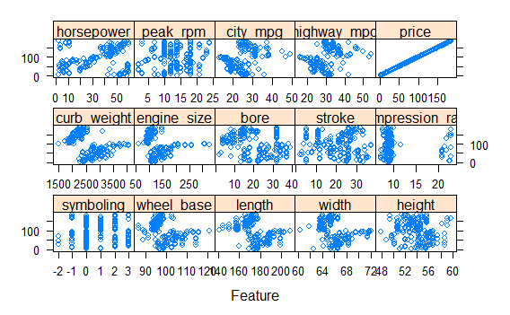

```r
library(caret)
featurePlot(cars,cars$price)
```

We will see the how many cars get sold in particular price ranges.

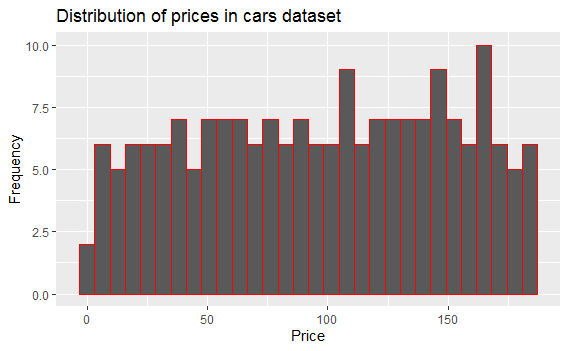

```r
ggplot(cars, aes(x = price)) +
  geom_histogram(color = "red") +
  labs(
    title = "Distribution of prices in cars dataset",
    x = "Price",
    y = "Frequency"
  )
```

It looks like there’s a reasonably even distirbution of the prices in the dataset, so there are no outliers. There are 2 cars whose price is zero, so this might be suspect. This only represents 1% of the entire dataset, so it shouldn’t have too much impact on predictions, especially if we use a high number of neighbors.

# Setting up the train-test split

The next step we need to take is to split the dataset into training and test sets. It is generally good to allocate most of the data to the training set.

```r
split_indices <- createDataPartition(cars$price, p = 0.8,  list = FALSE)
train_cars <- cars[split_indices,]
test_cars <- cars[-split_indices,]
```

# Cross - validation and hyperparameter optimization

About k-fold cross-validation, and we just need to decide how many folds we want to use. K-nearest neighbors is convenient for us because we only have to deal with one hyperparameter, but that shouldn’t stop us from choosing a wide range of values for k. caret does all of the testing for us behind the scenes.

```r
# 5-fold cross-validation
five_fold_control <- trainControl(method = "cv", number = 5)
tuning_grid <- expand.grid(k = 1:20)
```

# Experimenting with different models

With cross-validation and hyperparameter optimization in place, we are assured that each of the models is assessed in the same way, which enables us to compare them. Our ultimate goal with this guided project is to produce a model with the best possible predictions of car prices from the features we have. However, we don’t know ahead of time which combination of features will give us this model, so we’ll need to do a little bit of **experimentation**.

There’s no set way to approach this experimentation, One possible avenue is to start with all of the features in the dataset and see how this full model performs. Then, we could iteratively remove features to see if this improves or worsens the test error. Alternatively, we could iterate through all the features and see how well a single feature performs in prediction. After choosing the best one, we could add a second one that best improves performance, and so on.

The point is that choosing a final model resembles more an art than a science.

We could theoretically check all of the possible combinations of features since the number of feature columns is small. However, we wouldn’t be able to do this with even moderately larger datasets. Furthermore, you may come to a point where extra features only improve prediction ability by tiny amounts, so we’ll have to decide where to stop.

After some experimentation, lets pick one or a few models to keep as our “candidate” models. Use our lattice plot from earlier to help guide your decision.

```r
set.seed(1)
# Creating a model based on all the features
full_model <- train(price ~ .,
                    data = train_cars,
                    method = "knn",
                    trControl = five_fold_control,
                    tuneGrid = tuning_grid,
                    preProcess = c("center", "scale"))

full_model
```

```
k-Nearest Neighbors

158 samples
 14 predictor

Pre-processing: centered (14), scaled (14)
Resampling: Cross-Validated (5 fold)
Summary of sample sizes: 126, 128, 126, 126, 126
Resampling results across tuning parameters:

  k   RMSE      Rsquared   MAE
   1  57.76955  0.2168315  31.81583
   2  52.02681  0.2232603  32.33174
   3  51.55321  0.1979629  33.34437
   4  48.94710  0.2147611  33.32479
   5  47.27817  0.2454472  33.25310
   6  46.82158  0.2460099  33.29500
   7  45.19551  0.2881030  32.50747
   8  45.04292  0.2885644  33.00014
   9  45.33282  0.2818365  33.18438
  10  45.16652  0.2830709  33.25792
  11  45.24646  0.2791752  33.06682
  12  45.11441  0.2824731  32.77481
  13  44.92041  0.2880323  32.67542
  14  44.84030  0.2901708  32.65725
  15  44.92806  0.2892297  32.74626
  16  44.84215  0.2898483  32.87970
  17  44.76995  0.2932872  32.97234
  18  44.71440  0.2965351  33.00618
  19  44.51965  0.3014007  32.95148
  20  44.14860  0.3129233  32.75377

RMSE was used to select the optimal model using the
 smallest value.
The final value used for the model was k = 20.
```

Lets check with two features.

```r
two_feat_model <- train(price ~ city_mpg + highway_mpg,
                    data = train_cars,
                    method = "knn",
                    trControl = five_fold_control,
                    tuneGrid = tuning_grid,
                    preProcess = c("center", "scale"))

two_feat_model
```

```
k-Nearest Neighbors

158 samples
  2 predictor

Pre-processing: centered (2), scaled (2)
Resampling: Cross-Validated (5 fold)
Summary of sample sizes: 126, 126, 127, 127, 126
Resampling results across tuning parameters:

  k   RMSE      Rsquared   MAE
   1  51.54694  0.2667003  34.29628
   2  51.24027  0.2015359  35.23171
   3  51.15876  0.1739177  36.25063
   4  50.41658  0.1932786  36.09761
   5  48.26713  0.2398195  34.65451
   6  47.26710  0.2470168  34.30192
   7  47.45465  0.2379623  35.17685
   8  48.08128  0.2280147  36.28270
   9  48.24824  0.2109094  36.46717
  10  48.11479  0.2087471  36.66990
  11  48.75159  0.1906846  37.62189
  12  48.58059  0.1977494  37.67078
  13  48.05776  0.2141041  37.72145
  14  47.97822  0.2150976  37.62060
  15  48.21501  0.2065897  37.95992
  16  48.67870  0.1951085  38.22274
  17  48.66640  0.1941446  38.20245
  18  48.90155  0.1888817  38.33349
  19  48.73389  0.1911237  38.22797
  20  48.04711  0.2028227  37.75223

RMSE was used to select the optimal model using the
 smallest value.
The final value used for the model was k = 6.
```

**BAD** RMSE 47 and r squared 0.24

What about three features ?

```r
three_feat_model <- train(price ~ city_mpg + highway_mpg + stroke,
                    data = train_cars,
                    method = "knn",
                    trControl = five_fold_control,
                    tuneGrid = tuning_grid,
                    preProcess = c("center", "scale"))

three_feat_model
```

```
k-Nearest Neighbors

158 samples
  3 predictor

Pre-processing: centered (3), scaled (3)
Resampling: Cross-Validated (5 fold)
Summary of sample sizes: 126, 127, 127, 126, 126
Resampling results across tuning parameters:

  k   RMSE      Rsquared   MAE
   1  51.12720  0.2637462  31.39234
   2  49.61106  0.2600659  33.72789
   3  49.96010  0.2453794  35.27206
   4  49.01638  0.2375656  35.63646
   5  48.71298  0.2429489  36.29648
   6  48.09114  0.2522425  36.13609
   7  48.52570  0.2413236  36.19238
   8  48.91313  0.2165454  36.68737
   9  48.38296  0.2276703  36.35259
  10  47.93341  0.2318184  35.92162
  11  47.70245  0.2303637  36.31853
  12  46.94783  0.2445314  35.90988
  13  47.04387  0.2418009  36.36486
  14  47.44319  0.2326188  36.96897
  15  46.97025  0.2444709  36.56689
  16  47.05710  0.2372738  36.71043
  17  47.27976  0.2378869  37.00519
  18  47.45625  0.2301413  37.44247
  19  47.32813  0.2376572  37.32464
  20  47.56137  0.2269818  37.63584

RMSE was used to select the optimal model using the
 smallest value.
The final value used for the model was k = 12.
```

```r
two_feat_model_2 <- train(price ~ horsepower + city_mpg,
                    data = train_cars,
                    method = "knn",
                    trControl = five_fold_control,
                    tuneGrid = tuning_grid,
                    preProcess = c("center", "scale"))

two_feat_model_2
```

```
k-Nearest Neighbors

158 samples
  2 predictor

Pre-processing: centered (2), scaled (2)
Resampling: Cross-Validated (5 fold)
Summary of sample sizes: 126, 126, 126, 128, 126
Resampling results across tuning parameters:

  k   RMSE      Rsquared   MAE
   1  55.00133  0.1797077  34.49301
   2  51.56116  0.1777881  35.16404
   3  51.14169  0.1603970  36.83411
   4  49.96507  0.1674052  37.03821
   5  48.68284  0.1954587  36.43782
   6  47.51373  0.2121068  35.40505
   7  48.26474  0.1977535  36.46586
   8  48.25139  0.2018755  36.71311
   9  48.39130  0.1962404  36.79845
  10  48.95432  0.1799067  37.11598
  11  48.12965  0.1989569  36.78498
  12  47.83007  0.2101422  36.81496
  13  47.74299  0.2041247  36.85684
  14  47.68535  0.2041892  36.87900
  15  47.57575  0.2064708  37.04687
  16  47.56600  0.2070473  37.13838
  17  47.58753  0.2070160  37.30637
  18  47.60290  0.2062070  37.33802
  19  47.86623  0.1967505  37.34497
  20  48.21843  0.1986149  38.05051

RMSE was used to select the optimal model using the
 smallest value.
The final value used for the model was k = 6.
```

```r
two_feat_model_3 <- train(price ~ horsepower + engine_size,
                    data = train_cars,
                    method = "knn",
                    trControl = five_fold_control,
                    tuneGrid = tuning_grid,
                    preProcess = c("center", "scale"))

two_feat_model_3
```

```
k-Nearest Neighbors

158 samples
  2 predictor

Pre-processing: centered (2), scaled (2)
Resampling: Cross-Validated (5 fold)
Summary of sample sizes: 126, 127, 126, 126, 127
Resampling results across tuning parameters:

  k   RMSE      Rsquared   MAE
   1  51.48809  0.2766209  30.57852
   2  46.86633  0.3011485  29.09319
   3  46.52166  0.2938357  30.43971
   4  45.25118  0.3166727  30.62984
   5  46.13070  0.2786180  32.10726
   6  46.10003  0.2718751  32.61725
   7  46.25965  0.2639453  32.78263
   8  45.38480  0.2871315  32.47257
   9  46.04519  0.2677975  33.01119
  10  47.76937  0.2179525  34.21911
  11  47.73696  0.2146920  34.75147
  12  48.12639  0.1976770  35.30166
  13  47.80625  0.2011539  35.05858
  14  47.95693  0.1983585  35.40502
  15  48.02190  0.1959116  35.62020
  16  48.65070  0.1769889  36.17480
  17  48.89603  0.1672712  36.61738
  18  48.90060  0.1669549  36.95371
  19  49.04059  0.1655604  37.16622
  20  49.12678  0.1602335  37.52026

RMSE was used to select the optimal model using the
 smallest value.
The final value used for the model was k = 4.
```

Lets noodle some more.

```r
three_feat_model_3 <- train(price ~ horsepower + engine_size + highway_mpg,
                    data = train_cars,
                    method = "knn",
                    trControl = five_fold_control,
                    tuneGrid = tuning_grid,
                    preProcess = c("center", "scale"))

three_feat_model_3
```

```
k-Nearest Neighbors

158 samples
  3 predictor

Pre-processing: centered (3), scaled (3)
Resampling: Cross-Validated (5 fold)
Summary of sample sizes: 127, 126, 126, 127, 126
Resampling results across tuning parameters:

  k   RMSE      Rsquared   MAE
   1  49.49651  0.3009026  27.55796
   2  44.14224  0.3918493  27.23893
   3  43.30785  0.3731991  28.49110
   4  44.19684  0.3469550  29.96637
   5  44.86004  0.3152052  31.27103
   6  44.39045  0.3238382  31.87413
   7  45.00430  0.3040367  33.14394
   8  46.01527  0.2695433  34.24507
   9  46.80856  0.2422563  34.51025
  10  46.12777  0.2571083  34.18064
  11  45.94772  0.2661188  34.11717
  12  46.05942  0.2612446  34.80181
  13  46.62734  0.2471801  35.29245
  14  46.55978  0.2478364  35.09828
  15  46.80367  0.2431280  35.19097
  16  47.11980  0.2339253  35.50328
  17  47.18791  0.2383771  35.69746
  18  47.21348  0.2376158  35.73733
  19  47.13699  0.2386821  35.63372
  20  47.63909  0.2254513  36.17849

RMSE was used to select the optimal model using the
 smallest value.
The final value used for the model was k = 3.
```

**Not that much !**

```r
set.seed(1)
three_feat_model_4 <- train(price ~ horsepower + engine_size + curb_weight,
                    data = train_cars,
                    method = "knn",
                    trControl = five_fold_control,
                    tuneGrid = tuning_grid,
                    preProcess = c("center", "scale"))

three_feat_model_4
```

```
k-Nearest Neighbors

158 samples
  3 predictor

Pre-processing: centered (3), scaled (3)
Resampling: Cross-Validated (5 fold)
Summary of sample sizes: 126, 127, 127, 126, 126
Resampling results across tuning parameters:

  k   RMSE      Rsquared   MAE
   1  41.25978  0.4794489  24.00423
   2  41.04407  0.4510807  26.02765
   3  45.06863  0.3618122  28.90294
   4  43.54171  0.3935465  29.07659
   5  42.58804  0.4109626  28.70784
   6  42.51604  0.4033538  29.02347
   7  41.96225  0.4134845  29.03146
   8  42.77305  0.3910049  29.37176
   9  43.45029  0.3723278  29.93427
  10  43.03405  0.3842035  30.12198
  11  43.30111  0.3743216  30.45088
  12  43.91126  0.3560869  30.78626
  13  44.12623  0.3479341  30.83056
  14  43.62542  0.3589475  30.79764
  15  43.20028  0.3744989  30.88648
  16  43.41559  0.3657201  31.09796
  17  43.73701  0.3544002  31.57718
  18  43.75497  0.3513262  31.70833
  19  43.90525  0.3437793  32.20816
  20  43.72049  0.3435780  32.28084

RMSE was used to select the optimal model using the
 smallest value.
The final value used for the model was k = 2.
```

**Got it better this time** RMSE 41.04 and r squared is 45

```r
set.seed(1)
two_feat_model_4 <- train(price ~ engine_size + curb_weight,
                    data = train_cars,
                    method = "knn",
                    trControl = five_fold_control,
                    tuneGrid = tuning_grid,
                    preProcess = c("center", "scale"))
two_feat_model_4
```

```
k-Nearest Neighbors

158 samples
  2 predictor

Pre-processing: centered (2), scaled (2)
Resampling: Cross-Validated (5 fold)
Summary of sample sizes: 126, 127, 127, 126, 126
Resampling results across tuning parameters:

  k   RMSE      Rsquared   MAE
   1  47.31482  0.3970660  26.82238
   2  40.75776  0.4641885  26.76927
   3  41.33845  0.4352975  28.04602
   4  42.54750  0.3932098  29.06727
   5  43.64493  0.3539103  29.98634
   6  41.99279  0.3948228  29.76264
   7  41.34655  0.4021340  29.28110
   8  41.50915  0.3956828  29.30557
   9  41.97624  0.3854925  29.69779
  10  41.96552  0.3845737  29.98672
  11  41.24247  0.4050004  29.63379
  12  41.57248  0.3966167  29.74926
  13  41.28858  0.4051609  29.73025
  14  41.29775  0.4052946  29.86993
  15  40.90034  0.4153329  29.88974
  16  40.69299  0.4225696  29.60172
  17  40.37075  0.4308419  29.50698
  18  40.34030  0.4292551  29.60108
  19  40.02008  0.4361865  29.27949
  20  40.32974  0.4276611  29.47589

RMSE was used to select the optimal model using the
 smallest value.
The final value used for the model was k = 19.
```

**There we go** . RMSE = 40.02 and r squared = 0.43

But how about a single predictor ?

```r
one_feat_model <- train(price ~ curb_weight ,
                    data = train_cars,
                    method = "knn",
                    trControl = five_fold_control,
                    tuneGrid = tuning_grid,
                    preProcess = c("center", "scale"))

one_feat_model
```

```
k-Nearest Neighbors

158 samples
  1 predictor

Pre-processing: centered (1), scaled (1)
Resampling: Cross-Validated (5 fold)
Summary of sample sizes: 126, 126, 126, 126, 128
Resampling results across tuning parameters:

  k   RMSE      Rsquared   MAE
   1  43.89219  0.4162068  28.13104
   2  44.78013  0.3467183  29.30431
   3  42.06311  0.3991093  28.85872
   4  41.60629  0.3998636  28.88861
   5  40.33429  0.4308561  28.19723
   6  39.71230  0.4467100  27.46140
   7  39.79358  0.4462409  27.35588
   8  39.54267  0.4510868  27.21506
   9  39.47393  0.4525668  27.01751
  10  40.25672  0.4325853  27.67400
  11  40.02822  0.4338936  27.62119
  12  40.22416  0.4249058  28.06755
  13  40.12949  0.4280405  27.97473
  14  40.03881  0.4339517  27.90598
  15  40.19487  0.4270307  28.06037
  16  39.79340  0.4363712  27.79097
  17  39.52453  0.4417894  27.85381
  18  39.41739  0.4457158  28.01398
  19  39.37872  0.4462212  28.17367
  20  39.69172  0.4388410  28.38268

RMSE was used to select the optimal model using the
 smallest value.
The final value used for the model was k = 19.
```

**We got the best result using only one feature**. RMSE = 39.37. I dont know if we are going to the right direction or not. A lot of experimentation needed to find out.

Lets give two feature model another shot.

```r
set.seed(1)

two_feat_model_5 <- train(price ~ horsepower + curb_weight,
                    data = train_cars,
                    method = "knn",
                    trControl = five_fold_control,
                    tuneGrid = tuning_grid,
                    preProcess = c("center", "scale"))

two_feat_model_5
```

```
k-Nearest Neighbors

158 samples
  2 predictor

Pre-processing: centered (2), scaled (2)
Resampling: Cross-Validated (5 fold)
Summary of sample sizes: 126, 127, 127, 126, 126
Resampling results across tuning parameters:

  k   RMSE      Rsquared   MAE
   1  42.00724  0.4723420  22.29304
   2  38.55835  0.4994575  24.27266
   3  38.59580  0.4989991  25.17757
   4  39.06345  0.4844873  26.89722
   5  39.94061  0.4598785  27.03628
   6  41.20765  0.4224583  27.78039
   7  41.53896  0.4164791  28.73773
   8  41.90960  0.3998331  29.35340
   9  42.83069  0.3753902  29.91032
  10  43.17821  0.3615210  30.78538
  11  43.16842  0.3616004  30.78770
  12  43.31924  0.3561630  30.65878
  13  43.32307  0.3593108  31.08052
  14  43.33695  0.3568690  31.12961
  15  43.08107  0.3648316  31.12251
  16  43.39060  0.3578825  31.38819
  17  43.56564  0.3538899  31.46512
  18  43.75922  0.3482527  31.56982
  19  43.85030  0.3435437  31.83926
  20  44.29395  0.3313035  32.24470

RMSE was used to select the optimal model using the
 smallest value.
The final value used for the model was k = 2.
```

**This is the least RMSE we got so far** RMSE = 38.55

I want to use **10 fold** cross validation at this time using these two predictors.

```r
set.seed(1)
ten_fold_control <- trainControl(method = "cv", number = 10)
two_feat_model_6 <- train(price ~ horsepower + curb_weight,
                    data = train_cars,
                    method = "knn",
                    trControl = ten_fold_control,
                    tuneGrid = tuning_grid,
                    preProcess = c("center", "scale"))

two_feat_model_6
```

```
k-Nearest Neighbors

158 samples
  2 predictor

Pre-processing: centered (2), scaled (2)
Resampling: Cross-Validated (10 fold)
Summary of sample sizes: 142, 142, 143, 142, 143, 142, ...
Resampling results across tuning parameters:

  k   RMSE      Rsquared   MAE
   1  39.45067  0.5431563  23.16458
   2  37.52708  0.5226655  23.34455
   3  38.75302  0.4801148  24.59736
   4  39.82139  0.4488059  26.56769
   5  39.30936  0.4469577  26.17292
   6  40.46644  0.4108412  27.47521
   7  40.75351  0.4058029  28.19712
   8  40.69343  0.4154241  28.40770
   9  41.46247  0.3957110  28.97022
  10  42.09805  0.3811742  29.97987
  11  42.01175  0.3744152  30.27403
  12  42.70849  0.3563310  30.81394
  13  42.51417  0.3607970  30.60807
  14  42.44581  0.3626292  30.75780
  15  42.24706  0.3676517  30.74808
  16  42.23944  0.3681591  30.91851
  17  42.57481  0.3636018  31.16056
  18  42.79724  0.3637100  31.38742
  19  43.11376  0.3575731  31.64899
  20  43.23284  0.3533217  31.66876

RMSE was used to select the optimal model using the
 smallest value.
The final value used for the model was k = 2.
```

**Probably the best result so far**. RMSE = 37.52 and explains almost 53% of the data (r-sq)

# Final model evaluation

We will now predict against the test data using our knn models.

```r
predictions <- predict(full_model,  newdata = test_cars)
two_feat_prediction <- predict(two_feat_model,  newdata = test_cars)
two_feat_prediction_2 <- predict(two_feat_model_2,  newdata = test_cars)
two_feat_prediction_3 <- predict(two_feat_model_3,  newdata = test_cars)
two_feat_prediction_4 <- predict(two_feat_model_4,  newdata = test_cars)
two_feat_prediction_5 <- predict(two_feat_model_5,  newdata = test_cars)
two_feat_prediction_6 <- predict(two_feat_model_6,  newdata = test_cars)

three_feat_prediction <- predict(three_feat_model,  newdata = test_cars)
three_feat_prediction_2 <- predict(three_feat_model_2,  newdata = test_cars)
three_feat_prediction_3 <- predict(three_feat_model_3,  newdata = test_cars)
three_feat_prediction_4 <- predict(three_feat_model_4,  newdata = test_cars)

postResample(pred = predictions, obs = test_cars$price)
```

```
      RMSE   Rsquared        MAE
45.2175565  0.2640108 33.0060847
```

Now lets not print out all the postresamples this way, lets come back to post resample later and first lets make a table where we can see the summerized information about all the different models and predictions.

[output not shown]

[output cut: 26 more lines]

```r
test_cars %>%
  pivot_longer(
    cols =
      two_feat_prediction:
      two_feat_prediction_2:
      two_feat_prediction_3,
    names_to = "model",
    values_to = "predictions")
```

[output not shown]